# Pertemuan 5

Muhammad Nafiz

2023-09-26

### Import package yang dibutuhkan

```r
library(ggplot2)
library(tsibble)
library(tseries)
library(MASS)
```

### input data menjadi dataframe R

```r
data <- read.csv("https://raw.githubusercontent.com/MNafiz/MPDW/main/ambilData/hasilScrap.csv",header = T)
data
```

```
##       X      Waktu     Harga
## 1     0 2014-01-15 483177817
## 2     1 2014-02-15 464166759
## 3     2 2014-03-15 505600632
## 4     3 2014-04-15 478715808
## 5     4 2014-05-15 478465080
## 6     5 2014-06-15 483781045
## 7     6 2014-07-15 486579125
## 8     7 2014-08-15 489732148
## 9     8 2014-09-15 471472614
## 10    9 2014-10-15 489930981
## 11   10 2014-11-15 466876366
## 12   11 2014-12-15 492723811
## 13   12 2015-01-15 511722391
## 14   13 2015-02-15 489930981
```

[output cut: 102 more lines]

### Data Penuh

### Ubah ke bentuk data time series

```r
# decimal_date(ymd("2014-01-15"))
mts = ts(data$Harga,start = c(2014,1), frequency = 12)
mts
```

```
##            Jan       Feb       Mar       Apr       May       Jun       Jul
## 2014 483177817 464166759 505600632 478715808 478465080 483781045 486579125
## 2015 511722391 489930981 491574888 499624454 515587345 509726627 491617992
## 2016 486625341 507878091 517993722 522729132 544962466 553564154 560026608
## 2017 512279335 524883801 516109786 547562858 527604680 535072390 527164733
## 2018 574673064 566238967 581643358 594832562 582427570 571022277 573106367
## 2019 583229772 601213458 599236730 583145391 602832317 616957755 634620742
## 2020 683976334 673116056 728421675 866152347 838377492 787424909 851824885
## 2021 827558232 903533718 801736612 831476068 841701215 846928311 851171127
## 2022 836217092 804724763 888291980 911168929 849254440 861986434 822094437
## 2023 948727146 811785940 942011616 975666361 983118692 953689043 951975640
##            Aug       Sep       Oct       Nov       Dec
## 2014 489732148 471472614 489930981 466876366 492723811
## 2015 493067415 510044167 507878091 475041601 480281887
## 2016 565700778 557904318 524883801 525226891 483221053
## 2017 546244868 564066704 566238967 555959763 547537328
## 2018 553486363 569295070 601213458 576291752 578916974
## 2019 698954891 667641439 673116056 662978872 663347015
## 2020 932458299 936074215 903533718 864029384 842301754
## 2021 823153670 821914135 804724763 853152517 815691802
## 2022 841443321 798353629 811785940 882282860 892945377
## 2023 926756485
```

### Ringkasan dari data time series

```r
summary(mts)
```

```
##      Min.   1st Qu.    Median      Mean   3rd Qu.      Max.
## 464166759 517522738 582786480 661412907 828537691 983118692
```

### Plot data deret waktu

### Berasarkan plot deret waktu, data harga emas cenderung tidak stasioner dalam rataan dan ragam

### Hal ini dapat dilihat saat memasukki tahun 2020 dimana harga melonjak drastis dan fluktuaktifnya cenderung memiliki ragam yang lebih besar

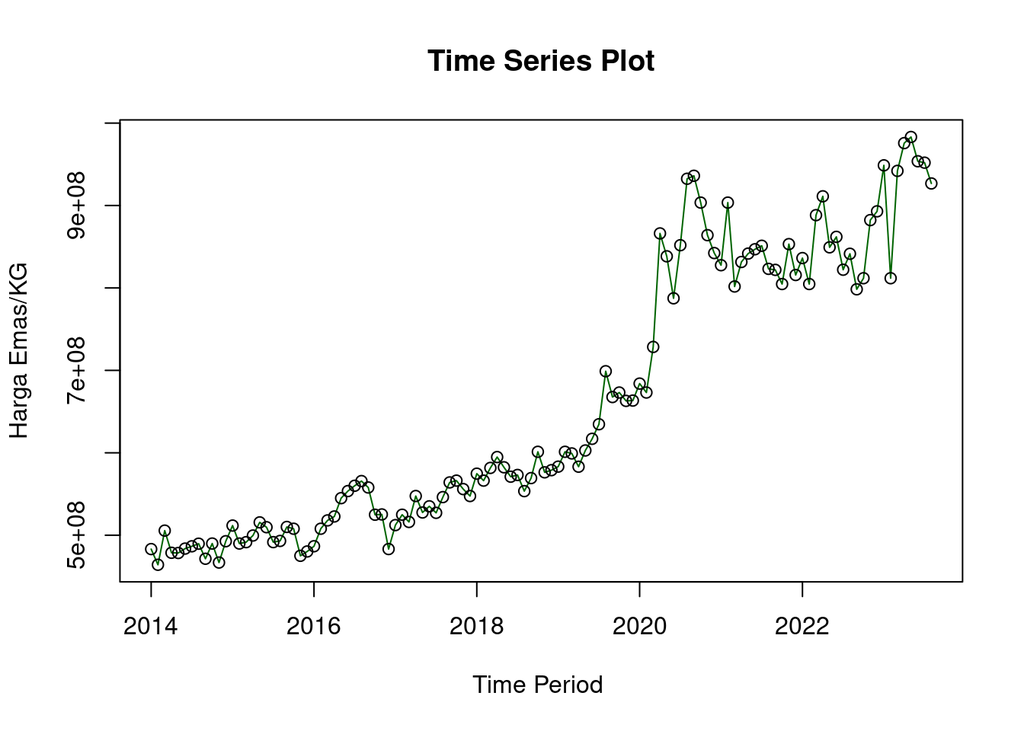

```r
ts.plot(mts, xlab="Time Period ", ylab="Harga Emas/KG",
        main = "Time Series Plot", col="darkgreen")
points(mts)
```

### Plot ACF

### Berdasarkan plot acf, acf yang dihasilkan cenderung slowly tail off

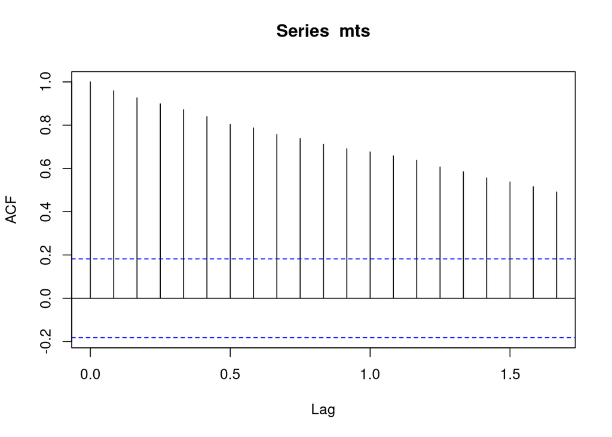

```r
acf(mts)
```

```r
tseries::adf.test(mts)
```

```
##
##  Augmented Dickey-Fuller Test
##
## data:  mts
## Dickey-Fuller = -2.16, Lag order = 4, p-value = 0.5102
## alternative hypothesis: stationary
```

$H_0$ : Data tidak stasioner dalam rataan

$H_1$ : Data stasioner dalam rataan

Berdasarkan uji ADF tersebut, didapat *p-value* sebesar 0.5102 yang lebih besar dari taraf nyata 5% sehingga tak tolak $H_0$ dan menandakan bahwa data tidak stasioner dalam rataan. Hal ini sesuai dengan hasil eksplorasi menggunakan plot time series dan plot ACF.

### Plot Box-Cox

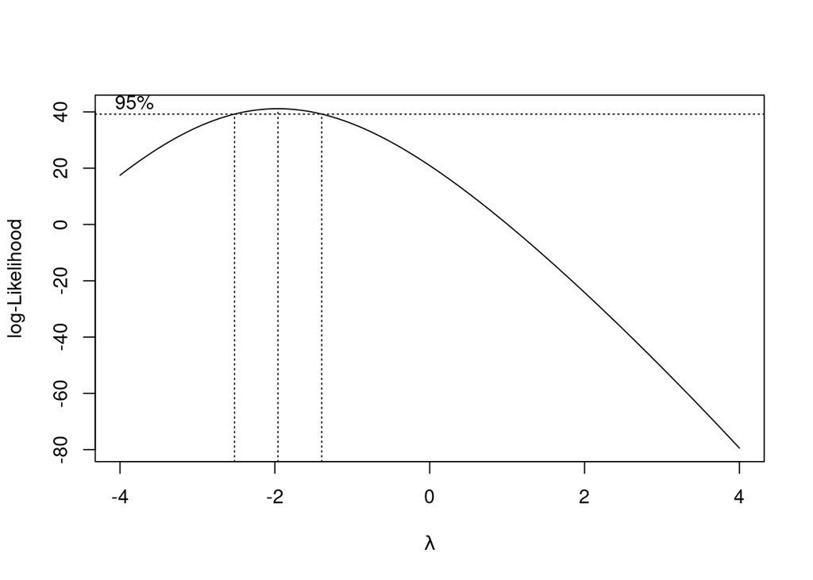

```r
index <- seq(1:length(mts))
bc = boxcox(mts~index, lambda = seq(-4,4,by=0.01))
```

```r
#Nilai Rounded Lambda
lambda <- bc$x[which.max(bc$y)]
lambda
```

```
## [1] -1.96
```

```r
#SK
bc$x[bc$y > max(bc$y) - 1/2 * qchisq(.95,1)]
```

```
##   [1] -2.52 -2.51 -2.50 -2.49 -2.48 -2.47 -2.46 -2.45 -2.44 -2.43 -2.42 -2.41
##  [13] -2.40 -2.39 -2.38 -2.37 -2.36 -2.35 -2.34 -2.33 -2.32 -2.31 -2.30 -2.29
##  [25] -2.28 -2.27 -2.26 -2.25 -2.24 -2.23 -2.22 -2.21 -2.20 -2.19 -2.18 -2.17
##  [37] -2.16 -2.15 -2.14 -2.13 -2.12 -2.11 -2.10 -2.09 -2.08 -2.07 -2.06 -2.05
##  [49] -2.04 -2.03 -2.02 -2.01 -2.00 -1.99 -1.98 -1.97 -1.96 -1.95 -1.94 -1.93
##  [61] -1.92 -1.91 -1.90 -1.89 -1.88 -1.87 -1.86 -1.85 -1.84 -1.83 -1.82 -1.81
##  [73] -1.80 -1.79 -1.78 -1.77 -1.76 -1.75 -1.74 -1.73 -1.72 -1.71 -1.70 -1.69
##  [85] -1.68 -1.67 -1.66 -1.65 -1.64 -1.63 -1.62 -1.61 -1.60 -1.59 -1.58 -1.57
##  [97] -1.56 -1.55 -1.54 -1.53 -1.52 -1.51 -1.50 -1.49 -1.48 -1.47 -1.46 -1.45
## [109] -1.44 -1.43 -1.42 -1.41 -1.40
```

Gambar di atas menunjukkan nilai *rounded value* ($\lambda$) optimum sebesar **-1,96** dan pada selang kepercayaan 95% nilai memiliki batas bawah **-2,52** dan batas atas **-1,40**. Selang tersebut tidak memuat nilai satu sehingga dapat dikatakan bahwa data tidak stasioner dalam ragam.

### Partisi Data

#### Bagian 1

```r
dt_stas1 <- mts[1:38] |> ts(start = c(2014,1), frequency = 12)
mean(dt_stas1)
```

```
## [1] 504084198
```

```r
var(dt_stas1)
```

```
## [1] 7.023669e+14
```

### Plot data deret waktu

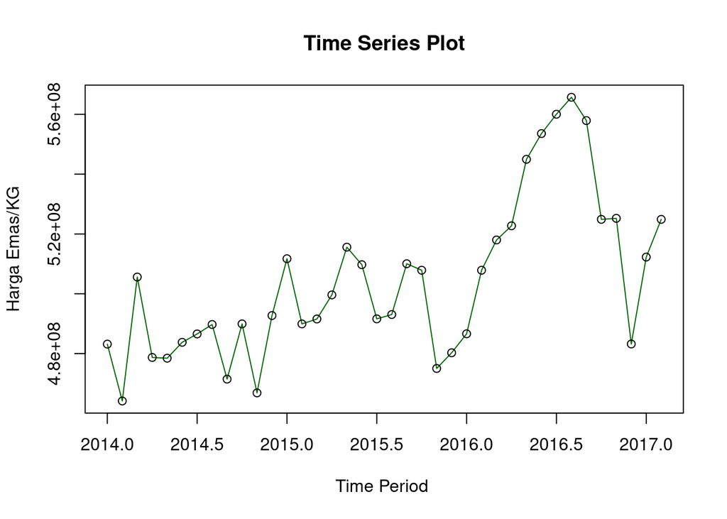

```r
ts.plot(dt_stas1, xlab="Time Period ", ylab="Harga Emas/KG",
        main = "Time Series Plot", col="darkgreen")
points(dt_stas1)
```

Plot deret waktu di atas menunjukkan bahwa data cenderung tidak stasioner dalam rataan, ditandai dengan data yang cenderung memiliki trend naik dan cenderung tidak stasioner dalam ragam, ditandai dengan lebar pita yang cenderung tidak sama.

### Plot ACF

### Berdasarkan plot acf, acf hanya signifikan sampai lag ke-4

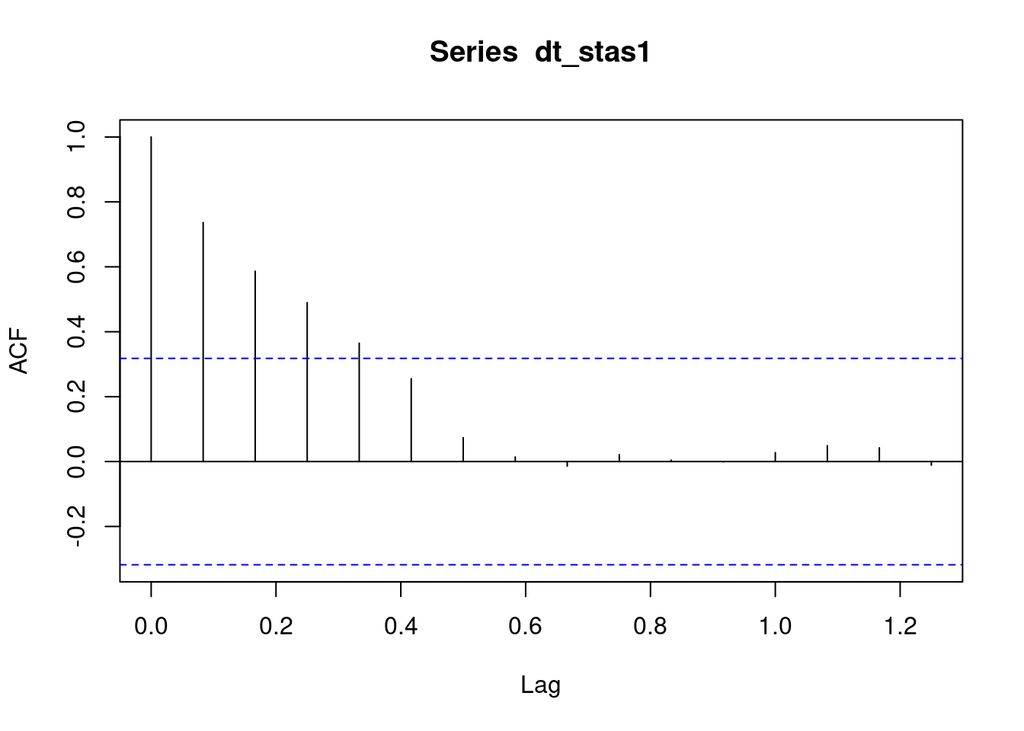

```r
acf(dt_stas1)
```

### Uji ADF

```r
tseries::adf.test(dt_stas1)
```

```
##
##  Augmented Dickey-Fuller Test
##
## data:  dt_stas1
## Dickey-Fuller = -2.8193, Lag order = 3, p-value = 0.2531
## alternative hypothesis: stationary
```

$H_0$ : Data tidak stasioner dalam rataan

$H_1$ : Data stasioner dalam rataan

Berdasarkan uji ADF tersebut, didapat *p-value* sebesar 0.2531 yang lebih besar dari taraf nyata 5% sehingga tak tolak $H_0$ dan menandakan bahwa data tidak stasioner dalam rataan. Hal ini sesuai dengan hasil eksplorasi menggunakan plot time series dan plot ACF.

### Plot Boxcox

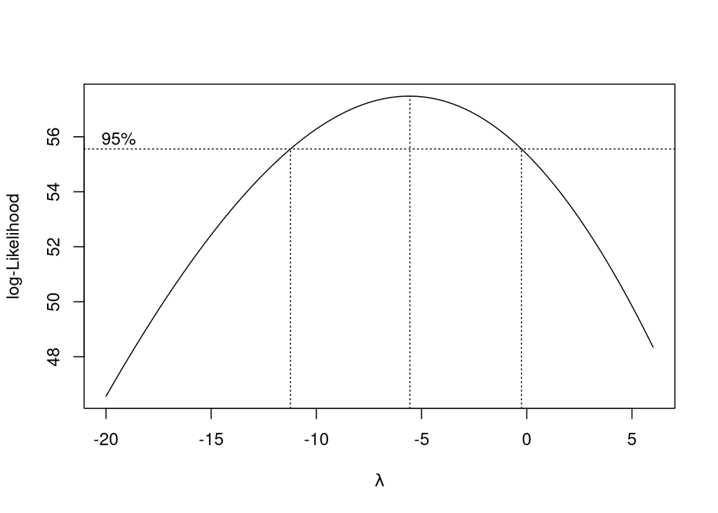

```r
index <- seq(1:38)
bc = boxcox(dt_stas1~index, lambda = seq(-20,6,by=1))
```

```r
#Nilai Rounded Lambda
lambda <- bc$x[which.max(bc$y)]
lambda
```

```
## [1] -5.555556
```

```r
#SK
bc$x[bc$y > max(bc$y) - 1/2 * qchisq(.95,1)]
```

```
##  [1] -11.0707071 -10.8080808 -10.5454545 -10.2828283 -10.0202020  -9.7575758
##  [7]  -9.4949495  -9.2323232  -8.9696970  -8.7070707  -8.4444444  -8.1818182
## [13]  -7.9191919  -7.6565657  -7.3939394  -7.1313131  -6.8686869  -6.6060606
## [19]  -6.3434343  -6.0808081  -5.8181818  -5.5555556  -5.2929293  -5.0303030
## [25]  -4.7676768  -4.5050505  -4.2424242  -3.9797980  -3.7171717  -3.4545455
## [31]  -3.1919192  -2.9292929  -2.6666667  -2.4040404  -2.1414141  -1.8787879
## [37]  -1.6161616  -1.3535354  -1.0909091  -0.8282828  -0.5656566  -0.3030303
```

Gambar di atas menunjukkan nilai *rounded value* ($\lambda$) optimum sebesar **-5,555556** dan pada selang kepercayaan 95% nilai memiliki batas bawah **-11.0707071** dan batas atas **-0.3030303**. Selang tersebut tidak memuat nilai satu sehingga dapat dikatakan bahwa data harga emas partisi 1 tidak stasioner dalam ragam.

### Bagian 2

### Data partisi 2

```r
dt_stas2 <- mts[1:77] |> ts(start = c(2014,1), frequency = 12)
mean(dt_stas2)
```

```
## [1] 557002957
```

```r
var(dt_stas2)
```

```
## [1] 6.081917e+15
```

### Plot data deret waktu

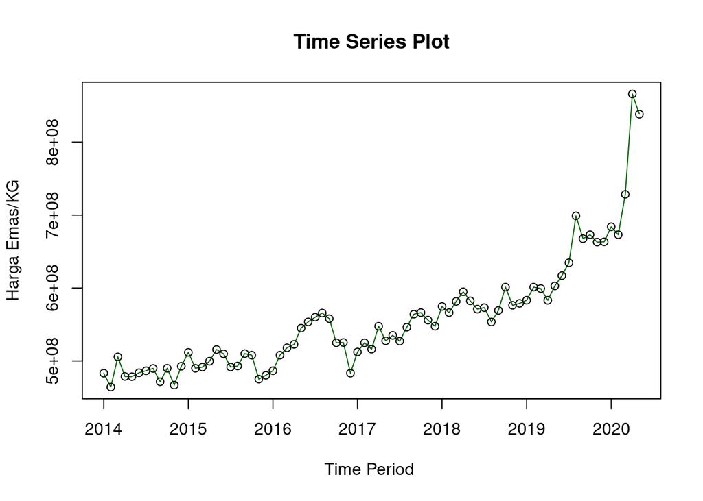

```r
ts.plot(dt_stas2, xlab="Time Period ", ylab="Harga Emas/KG",
        main = "Time Series Plot", col="darkgreen")
points(dt_stas2)
```

Plot deret waktu di atas menunjukkan bahwa data cenderung tidak stasioner dalam rataan, ditandai dengan data yang tiba tiba meningkat drastis memasuki tahun 2020 dan cenderung tidak stasioner dalam ragam, ditandai dengan lebar pita yang cenderung tidak sama.

#### Plot ACF

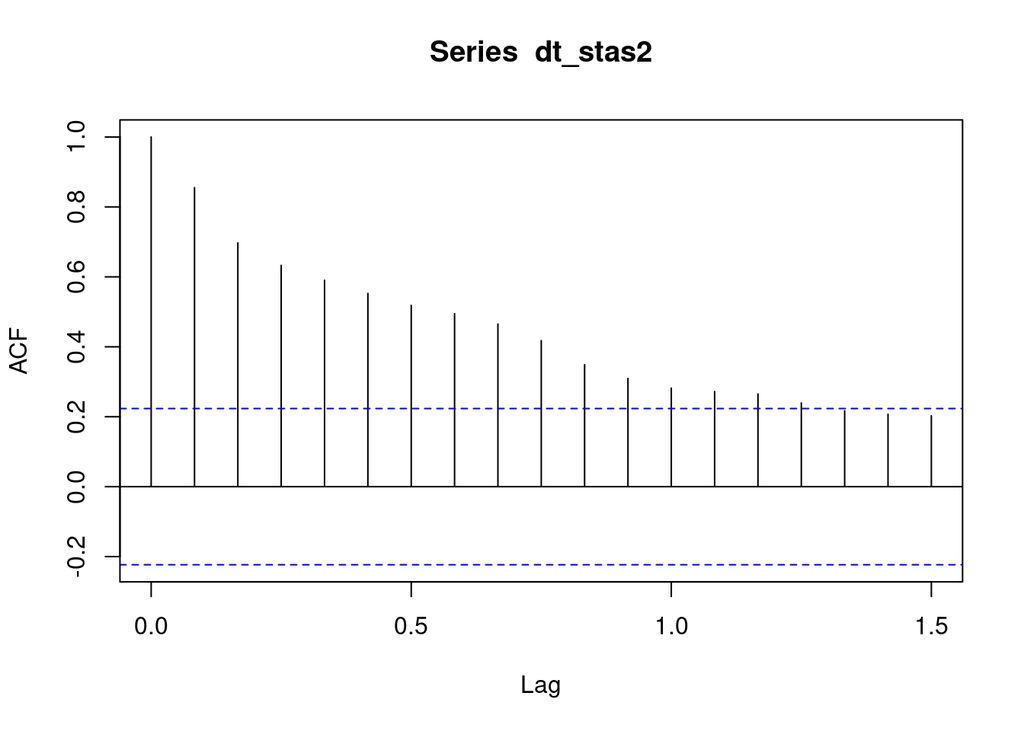

```r
acf(dt_stas2)
```

Berdasarkan plot ACF, terlihat bahwa plot ACF pada data tersebut cenderung *tails off*

#### Uji ADF

```r
adf.test(dt_stas2)
```

```
##
##  Augmented Dickey-Fuller Test
##
## data:  dt_stas2
## Dickey-Fuller = 0.59169, Lag order = 4, p-value = 0.99
## alternative hypothesis: stationary
```

$H_0$ : Data tidak stasioner dalam rataan

$H_1$ : Data stasioner dalam rataan

Berdasarkan uji ADF tersebut, didapat *p-value* sebesar 0.99 yang lebih besar dari taraf nyata 5% sehingga tak tolak $H_0$ dan menandakan bahwa data tidak stasioner dalam rataan. Hal ini sesuai dengan hasil eksplorasi menggunakan plot time series dan plot ACF.

#### Plot Boxcox

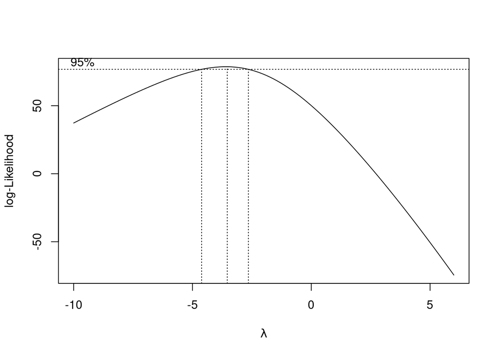

```r
index <- seq(1:77)
bc = boxcox(dt_stas2~index, lambda = seq(-10,6,by=1))
```

```r
#Nilai Rounded Lambda
lambda <- bc$x[which.max(bc$y)]
lambda
```

```
## [1] -3.535354
```

```r
#SK
bc$x[bc$y > max(bc$y) - 1/2 * qchisq(.95,1)]
```

```
##  [1] -4.505051 -4.343434 -4.181818 -4.020202 -3.858586 -3.696970 -3.535354
##  [8] -3.373737 -3.212121 -3.050505 -2.888889 -2.727273
```

Gambar di atas menunjukkan nilai *rounded value* ($\lambda$) optimum sebesar **-3.535354** dan pada selang kepercayaan 95% nilai memiliki batas bawah **-4.505051** dan batas atas **-2.727273**. Selang tersebut tidak memuat nilai satu sehingga dapat dikatakan bahwa data harga emas partisi 2 tidak stasioner dalam ragam.